# hyperparameter-tuning

# Final Model Verification

The show_best(), select_best(), and collect_metrics() functions are all great, but they are only implemented on the resampled iterations of the training data. Remember, applications over just the training data can often be misleading. We need to check the final model on the test data to see how it performs.

Here, we can leverage a short cut in tidymodels to fit the final model to the test data. This is done using the last_fit() function. The last_fit() function will take the finalized workflow, and the full split data object (containing both the training and testing data) and fit it to the training data and validate it on the testing data.

Use last_fit() to fit the finalized workflow the original split object (output of initial_split()). This will fit the model to the training data and validate it on the testing data.

```r
last_fit_results <- last_fit(final_wf, split = camels_split)
```

With the final model fit, we can now check the performance of the model on the test data in our two standard ways!

Use the collect_metrics() function to check the performance of the final model on the test data. This will return a tibble with the metrics for the final model. Interpret these results. How does the final model perform on the test data? Is it better or worse than the training data? Use your knowledge of the regression based metrics to describe the results.

```r
# Collect metrics for the final model on the test data
final_model_metrics <- collect_metrics(last_fit_results)

#show results
final_model_metrics
```

```
# A tibble: 2 × 4
  .metric .estimator .estimate .config
  <chr>   <chr>          <dbl> <chr>
1 rmse    standard       0.535 Preprocessor1_Model1
2 rsq     standard       0.777 Preprocessor1_Model1
```

Use the collect_predictions() function to check the predictions of the final model on the test data. This will return a tibble with the predictions for the final model.

```r
# Fit the final model and collect predictions using last_fit
final_fit <- last_fit(final_wf, split = camels_split)

# Use collect_predictions() to get the predictions
final_predictions <- collect_predictions(final_fit)

# View the first few rows of predictions
head(predictions)
```

[output not shown]

[output not shown]

```
1 function (x, ...)
2 UseMethod("predictions")
```

Use the output of this to create a scatter plot of the predicted values vs the actual values. Use the ggplot2 package to create the plot. This plot should include (1) geom_smooth(method = “lm”) to add the linear fit of predictions and truth (2) geom_abline() to add a 1:1 line (3) nice colors via scale_color_* and (4) accurate labels.

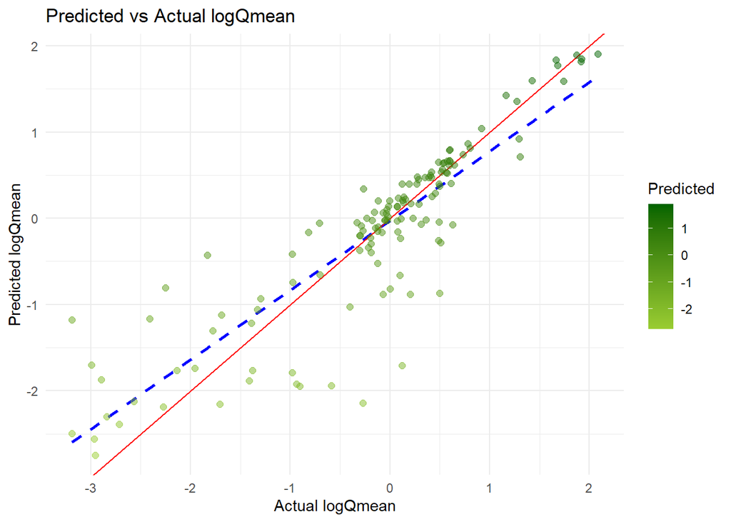

```r
# Create the scatter plot with a color gradient
ggplot(final_predictions, aes(x = logQmean, y = .pred)) +
  # (1) Linear trend line of predictions vs actuals
  geom_smooth(method = "lm", se = FALSE, color = "blue", linetype = "dashed") +

  # (2) 1:1 reference line (perfect prediction)
  geom_abline(slope = 1, intercept = 0, color = "red", linetype = "solid") +

  # (3) Points with green color scale
  geom_point(aes(color = .pred), size = 2, alpha = 0.5) +
  scale_color_gradient(low = "yellowgreen", high = "darkgreen") +

  # (4) Labels and theme
  labs(
    title = "Predicted vs Actual logQmean",
    x = "Actual logQmean",
    y = "Predicted logQmean",
    color = "Predicted"
  ) +
  theme_minimal()
```

```r
#linear fit line (blue dashed line) will show the trend of predictions vs. actual values.

#The 1:1 line (red solid line) will show where predicted values equal actual values.
```

# Building a Map!

As a last step, you want to map your predictions across CONUS. Return to the ggplot examples in Lab 6 to refresh your memory on building a map with a defined color pallete.

To build your final prediction, you can use fit() to fit the finalized workflow to the full, cleaned data (prior to splitting). This will return a fitted model object that can be used to make predictions on new data.

This full fit can be passed to the augment() function to make predictions on the full, cleaned data. This will return a tibble with the predictions for the full data. Use the mutate() function to calculate the residuals of the predictions. The residuals are the difference between the predicted values and the actual values squared.

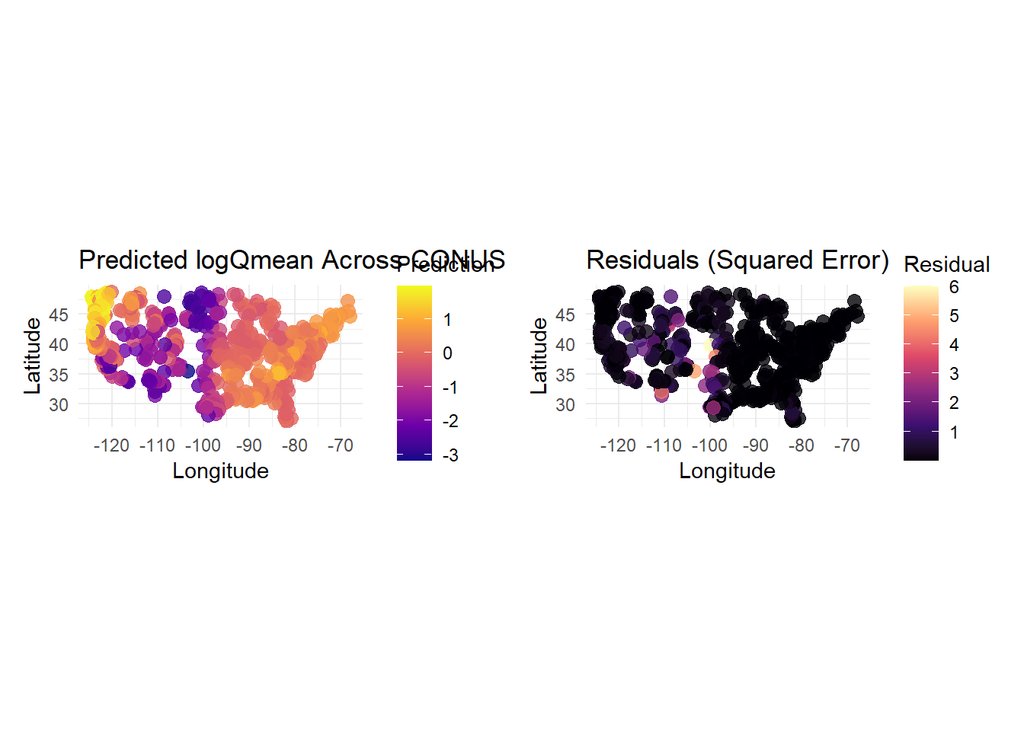

```r
# Fit the final model to the entire dataset
final_fit <- fit(final_wf, data = camels_clean)

# Get predictions for the full dataset
full_predictions <- augment(final_fit, new_data = camels_clean)

#Calculate residuals
full_predictions <- full_predictions %>%
  mutate(residual = (logQmean - .pred)^2)

#Use ggplot2 to create a map of the predictions.
us_map <- map_data("state")

predic_plot<-ggplot(full_predictions, aes(x = gauge_lon, y = gauge_lat)) +
  geom_point(aes(color = .pred), size = 3, alpha = 0.8) +
  scale_color_viridis_c(option = "C") +  # You can switch palettes here
  coord_fixed(1.3) +  # keep geographic aspect ratio
  labs(
    title = "Predicted logQmean Across CONUS",
    x = "Longitude",
    y = "Latitude",
    color = "Prediction"
  ) +
  theme_minimal()

#use ggplot to creat map of residuals

residuals_plot<-  ggplot(full_predictions, aes(x = gauge_lon, y = gauge_lat)) +
  geom_point(aes(color = residual), size = 3, alpha = 0.8) +
  scale_color_viridis_c(option = "magma") +
  coord_fixed(1.3) +
  labs(
    title = "Residuals (Squared Error)",
    x = "Longitude",
    y = "Latitude",
    color = "Residual"
  ) +
  theme_minimal()


# Combine the two maps into a single image using patchwork
combined_plot <- predic_plot | residuals_plot

combined_plot
```